# Project: tmdb-movies Data Analysis

- Introduction
- Data Wrangling
- Exploratory Data Analysis
- Conclusions

## Introduction

This report analyses "tmdb-movies" dataset which contains information about 10,000 movies collected from The Movie Database (TMDb), including user ratings and revenue. The movie industry is exciting as it's full of surprises. A movie can bring back millions dollar of profit. Hence, this report studies the following 2 questions.

1) Which genres are most popular thorough the years?

2) What kinds of properties are associated with movies that have high revenues?

```python
import pandas as pd
import numpy as np
%matplotlib inline
import matplotlib.pyplot as plt
import seaborn as sns
```

## Data Wrangling

### General Properties

```python
# Load your data and print out a few lines. Perform operations to inspect data
#   types and look for instances of missing or possibly errant data.
df = pd.read_csv('tmdb-movies.csv')
df.head(10)
```

|  | id | imdb_id | popularity | budget | revenue | original_title | cast | homepage | director | tagline | ... | overview | runtime | genres | production_companies | release_date | vote_count | vote_average | release_year | budget_adj | revenue_adj |
| --- | --- | --- | --- | --- | --- | --- | --- | --- | --- | --- | --- | --- | --- | --- | --- | --- | --- | --- | --- | --- | --- |
| 0 | 135397 | tt0369610 | 32.985763 | 150000000 | 1513528810 | Jurassic World | Chris Pratt\|Bryce Dallas Howard\|Irrfan Khan\|Vi... | http://www.jurassicworld.com/ | Colin Trevorrow | The park is open. | ... | Twenty-two years after the events of Jurassic ... | 124 | Action\|Adventure\|Science Fiction\|Thriller | Universal Studios\|Amblin Entertainment\|Legenda... | 6/9/15 | 5562 | 6.5 | 2015 | 1.379999e+08 | 1.392446e+09 |
| 1 | 76341 | tt1392190 | 28.419936 | 150000000 | 378436354 | Mad Max: Fury Road | Tom Hardy\|Charlize Theron\|Hugh Keays-Byrne\|Nic... | http://www.madmaxmovie.com/ | George Miller | What a Lovely Day. | ... | An apocalyptic story set in the furthest reach... | 120 | Action\|Adventure\|Science Fiction\|Thriller | Village Roadshow Pictures\|Kennedy Miller Produ... | 5/13/15 | 6185 | 7.1 | 2015 | 1.379999e+08 | 3.481613e+08 |
| 2 | 262500 | tt2908446 | 13.112507 | 110000000 | 295238201 | Insurgent | Shailene Woodley\|Theo James\|Kate Winslet\|Ansel... | http://www.thedivergentseries.movie/#insurgent | Robert Schwentke | One Choice Can Destroy You | ... | Beatrice Prior must confront her inner demons ... | 119 | Adventure\|Science Fiction\|Thriller | Summit Entertainment\|Mandeville Films\|Red Wago... | 3/18/15 | 2480 | 6.3 | 2015 | 1.012000e+08 | 2.716190e+08 |
| 3 | 140607 | tt2488496 | 11.173104 | 200000000 | 2068178225 | Star Wars: The Force Awakens | Harrison Ford\|Mark Hamill\|Carrie Fisher\|Adam D... | http://www.starwars.com/films/star-wars-episod... | J.J. Abrams | Every generation has a story. | ... | Thirty years after defeating the Galactic Empi... | 136 | Action\|Adventure\|Science Fiction\|Fantasy | Lucasfilm\|Truenorth Productions\|Bad Robot | 12/15/15 | 5292 | 7.5 | 2015 | 1.839999e+08 | 1.902723e+09 |
| 4 | 168259 | tt2820852 | 9.335014 | 190000000 | 1506249360 | Furious 7 | Vin Diesel\|Paul Walker\|Jason Statham\|Michelle ... | http://www.furious7.com/ | James Wan | Vengeance Hits Home | ... | Deckard Shaw seeks revenge against Dominic Tor... | 137 | Action\|Crime\|Thriller | Universal Pictures\|Original Film\|Media Rights ... | 4/1/15 | 2947 | 7.3 | 2015 | 1.747999e+08 | 1.385749e+09 |
| 5 | 281957 | tt1663202 | 9.110700 | 135000000 | 532950503 | The Revenant | Leonardo DiCaprio\|Tom Hardy\|Will Poulter\|Domhn... | http://www.foxmovies.com/movies/the-revenant | Alejandro González Iñárritu | (n. One who has returned, as if from the dead.) | ... | In the 1820s, a frontiersman, Hugh Glass, sets... | 156 | Western\|Drama\|Adventure\|Thriller | Regency Enterprises\|Appian Way\|CatchPlay\|Anony... | 12/25/15 | 3929 | 7.2 | 2015 | 1.241999e+08 | 4.903142e+08 |
| 6 | 87101 | tt1340138 | 8.654359 | 155000000 | 440603537 | Terminator Genisys | Arnold Schwarzenegger\|Jason Clarke\|Emilia Clar... | http://www.terminatormovie.com/ | Alan Taylor | Reset the future | ... | The year is 2029. John Connor, leader of the r... | 125 | Science Fiction\|Action\|Thriller\|Adventure | Paramount Pictures\|Skydance Productions | 6/23/15 | 2598 | 5.8 | 2015 | 1.425999e+08 | 4.053551e+08 |
| 7 | 286217 | tt3659388 | 7.667400 | 108000000 | 595380321 | The Martian | Matt Damon\|Jessica Chastain\|Kristen Wiig\|Jeff ... | http://www.foxmovies.com/movies/the-martian | Ridley Scott | Bring Him Home | ... | During a manned mission to Mars, Astronaut Mar... | 141 | Drama\|Adventure\|Science Fiction | Twentieth Century Fox Film Corporation\|Scott F... | 9/30/15 | 4572 | 7.6 | 2015 | 9.935996e+07 | 5.477497e+08 |
| 8 | 211672 | tt2293640 | 7.404165 | 74000000 | 1156730962 | Minions | Sandra Bullock\|Jon Hamm\|Michael Keaton\|Allison... | http://www.minionsmovie.com/ | Kyle Balda\|Pierre Coffin | Before Gru, they had a history of bad bosses | ... | Minions Stuart, Kevin and Bob are recruited by... | 91 | Family\|Animation\|Adventure\|Comedy | Universal Pictures\|Illumination Entertainment | 6/17/15 | 2893 | 6.5 | 2015 | 6.807997e+07 | 1.064192e+09 |
| 9 | 150540 | tt2096673 | 6.326804 | 175000000 | 853708609 | Inside Out | Amy Poehler\|Phyllis Smith\|Richard Kind\|Bill Ha... | http://movies.disney.com/inside-out | Pete Docter | Meet the little voices inside your head. | ... | Growing up can be a bumpy road, and it's no ex... | 94 | Comedy\|Animation\|Family | Walt Disney Pictures\|Pixar Animation Studios\|W... | 6/9/15 | 3935 | 8.0 | 2015 | 1.609999e+08 | 7.854116e+08 |

10 rows × 21 columns

#### The first few rows show that "cast", "genres", "director" and "production_companies" features contain "|" in their values.

```python
df.shape
```

```
(10866, 21)
```

```python
df.describe()
```

|  | id | popularity | budget | revenue | runtime | vote_count | vote_average | release_year | budget_adj | revenue_adj |
| --- | --- | --- | --- | --- | --- | --- | --- | --- | --- | --- |
| count | 10866.000000 | 10866.000000 | 1.086600e+04 | 1.086600e+04 | 10866.000000 | 10866.000000 | 10866.000000 | 10866.000000 | 1.086600e+04 | 1.086600e+04 |
| mean | 66064.177434 | 0.646441 | 1.462570e+07 | 3.982332e+07 | 102.070863 | 217.389748 | 5.974922 | 2001.322658 | 1.755104e+07 | 5.136436e+07 |
| std | 92130.136561 | 1.000185 | 3.091321e+07 | 1.170035e+08 | 31.381405 | 575.619058 | 0.935142 | 12.812941 | 3.430616e+07 | 1.446325e+08 |
| min | 5.000000 | 0.000065 | 0.000000e+00 | 0.000000e+00 | 0.000000 | 10.000000 | 1.500000 | 1960.000000 | 0.000000e+00 | 0.000000e+00 |
| 25% | 10596.250000 | 0.207583 | 0.000000e+00 | 0.000000e+00 | 90.000000 | 17.000000 | 5.400000 | 1995.000000 | 0.000000e+00 | 0.000000e+00 |
| 50% | 20669.000000 | 0.383856 | 0.000000e+00 | 0.000000e+00 | 99.000000 | 38.000000 | 6.000000 | 2006.000000 | 0.000000e+00 | 0.000000e+00 |
| 75% | 75610.000000 | 0.713817 | 1.500000e+07 | 2.400000e+07 | 111.000000 | 145.750000 | 6.600000 | 2011.000000 | 2.085325e+07 | 3.369710e+07 |
| max | 417859.000000 | 32.985763 | 4.250000e+08 | 2.781506e+09 | 900.000000 | 9767.000000 | 9.200000 | 2015.000000 | 4.250000e+08 | 2.827124e+09 |

#### From the description above,:

- "budget", "revenue", "runtime", "budget_adj" and "revenue_adj" have values of 0.
- popularity seems to have outliner since its Max value is 32, while its min is 0.000065

```python
df.info()
```

```
<class 'pandas.core.frame.DataFrame'>
RangeIndex: 10866 entries, 0 to 10865
Data columns (total 21 columns):
id                      10866 non-null int64
imdb_id                 10856 non-null object
popularity              10866 non-null float64
budget                  10866 non-null int64
revenue                 10866 non-null int64
original_title          10866 non-null object
cast                    10790 non-null object
homepage                2936 non-null object
director                10822 non-null object
tagline                 8042 non-null object
keywords                9373 non-null object
overview                10862 non-null object
runtime                 10866 non-null int64
genres                  10843 non-null object
production_companies    9836 non-null object
release_date            10866 non-null object
vote_count              10866 non-null int64
vote_average            10866 non-null float64
release_year            10866 non-null int64
budget_adj              10866 non-null float64
revenue_adj             10866 non-null float64
dtypes: float64(4), int64(6), object(11)
memory usage: 1.7+ MB
```

#### Among 21 columns, the following columns have Null values:

- imdb_id
- cast
- homepage
- director
- tagline
- keywords
- overview
- genres
- production_companies

```python
#Inspect the data of few features to analyse their values
print(df['keywords'].head(10))

print(df['overview'].head(10))

print(df['tagline'].head(10))
```

```
0    monster|dna|tyrannosaurus rex|velociraptor|island
1     future|chase|post-apocalyptic|dystopia|australia
2    based on novel|revolution|dystopia|sequel|dyst...
3                android|spaceship|jedi|space opera|3d
4                  car race|speed|revenge|suspense|car
5    father-son relationship|rape|based on novel|mo...
6    saving the world|artificial intelligence|cybor...
7          based on novel|mars|nasa|isolation|botanist
8    assistant|aftercreditsstinger|duringcreditssti...
9         dream|cartoon|imaginary friend|animation|kid
Name: keywords, dtype: object
0    Twenty-two years after the events of Jurassic ...
1    An apocalyptic story set in the furthest reach...
2    Beatrice Prior must confront her inner demons ...
3    Thirty years after defeating the Galactic Empi...
```

[output cut: 18 more lines]

### The "keyword" feature seems to be useful as it has important keywords about the movie content. Meanwhile, "overview" contains too much details about the content, and "tagline" contains too little details; hence, both of them can be dropped from the dataframe.

## Data Cleaning

```python
#Drop the features with too many Null values, and those that are not important to the analysis
df.drop(['imdb_id','homepage','tagline','overview'],axis=1,inplace=True)

# As the columns contains Strings, their null values will be changed to ''
df.fillna({'genres':'', 'cast':'', 'director':'', 'keywords':'', 'production_companies': ''},inplace=True)

#To verify if there's any NULL value left in the Dataframe, the result should be FALSE
print(df.isnull().sum().any())
```

```
False
```

```python
# Verify that the 4 features have been dropped, and the dataframe now has 17 columns
df.shape
```

```
(10866, 17)
```

#### Look for duplicate observations in the dataset

```python
df.loc[df.duplicated(keep=False),:]
```

[output not shown]

```python
#Remove the duplicate observations:
df.drop_duplicates(keep='first',inplace=True)
```

```python
df.shape
```

```
(10865, 17)
```

### Though it seems obvious that budget_adj & revenue_adj are derived from budget and revenue, the quick look below at the counts of the 4 features just to verify that they are equal correspondingly.

```python
print(df[df['budget_adj']==0].count())
print(df[df['budget']==0].count())
print(df[df['revenue_adj']==0].count())
print(df[df['revenue']==0].count())
```

```
id                      5696
popularity              5696
budget                  5696
revenue                 5696
original_title          5696
cast                    5696
director                5696
keywords                5696
runtime                 5696
genres                  5696
production_companies    5696
release_date            5696
vote_count              5696
vote_average            5696
release_year            5696
budget_adj              5696
revenue_adj             5696
dtype: int64
id                      5696
popularity              5696
budget                  5696
revenue                 5696
original_title          5696
cast                    5696
director                5696
keywords                5696
runtime                 5696
genres                  5696
production_companies    5696
release_date            5696
vote_count              5696
vote_average            5696
release_year            5696
budget_adj              5696
revenue_adj             5696
dtype: int64
id                      6016
popularity              6016
budget                  6016
revenue                 6016
```

[output cut: 17 more lines]

```
revenue                 6016
original_title          6016
cast                    6016
director                6016
keywords                6016
runtime                 6016
genres                  6016
production_companies    6016
release_date            6016
vote_count              6016
vote_average            6016
release_year            6016
budget_adj              6016
revenue_adj             6016
dtype: int64
```

#### The diagrams below show that the movies with budget_adj=0 are released across all the years listed in the dataframe, not just in any specific timeframe.

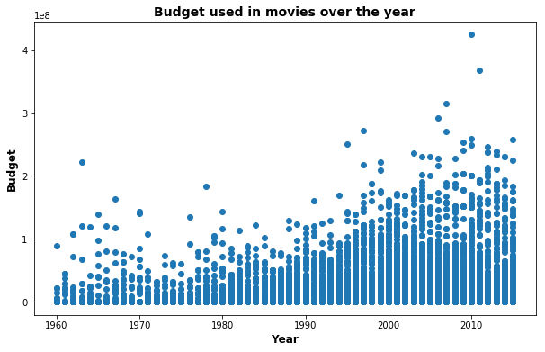

```python
plt.figure(figsize=(10, 6))
plt.scatter(df.release_year,df.budget_adj);
plt.title('Budget used in movies over the year',fontsize=14, fontweight='bold')
plt.xlabel('Year',fontsize=12, fontweight='bold')
plt.ylabel('Budget',fontsize=12, fontweight='bold');
```

#### A closer look at the budget_adj via box-plot and scatter-plot below:

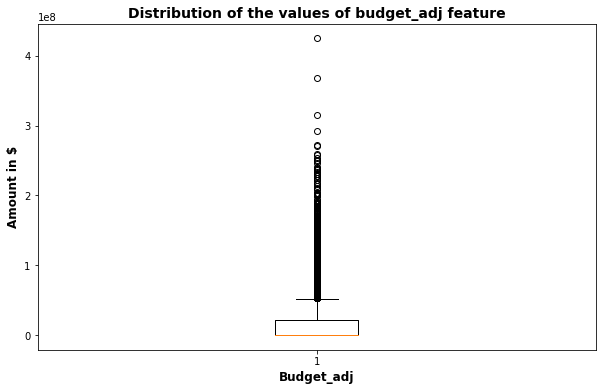

```python
plt.figure(figsize=(10, 6))
plt.boxplot(df.budget_adj);
plt.title('Distribution of the values of budget_adj feature',fontsize=14, fontweight='bold')
plt.xlabel('Budget_adj',fontsize=12, fontweight='bold')
plt.ylabel('Amount in $',fontsize=12, fontweight='bold');
```

### As 5696 movies out of 10866 (i.e. > 50%) with budget_adj = 0, the budget_adj will be imputed with a value. Among the feature's mean, mode and median, mean is chosen because the other two are 0.

```python
print(df.budget_adj.mode())
print(df.budget_adj.median())
print(df.budget_adj.mean())
```

```
0    0.0
dtype: float64
0.0
17551039.82288678
```

```python
df.replace({'budget_adj':0,},df.budget_adj.mean(),inplace=True)

#To verify that all budget_adj=0 are now replaced, so the expected counts should be 0
print(df[df['budget_adj']==0].count())
```

```
id                      0
popularity              0
budget                  0
revenue                 0
original_title          0
cast                    0
director                0
keywords                0
runtime                 0
genres                  0
production_companies    0
release_date            0
vote_count              0
vote_average            0
release_year            0
budget_adj              0
revenue_adj             0
dtype: int64
```

#### The diagrams below shows that movies with revenue_adj=0 are released across all the years listed in the dataframe, not just in any specific timeframe.

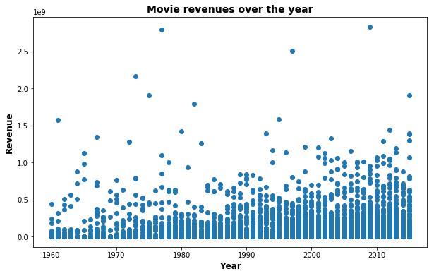

```python
plt.figure(figsize=(10, 6))
plt.scatter(df.release_year,df.revenue_adj);
plt.title('Movie revenues over the year',fontsize=14, fontweight='bold')
plt.xlabel('Year',fontsize=12, fontweight='bold')
plt.ylabel('Revenue',fontsize=12, fontweight='bold');
```

#### A closer look at the revenue_adj via box-plot and scatter-plot below:

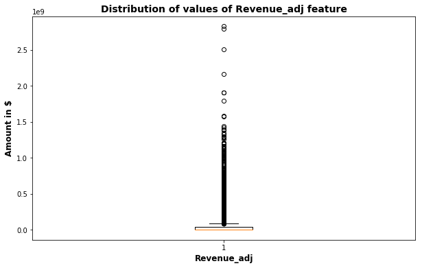

```python
plt.figure(figsize=(10,6))
plt.boxplot(df.revenue_adj);
plt.title('Distribution of values of Revenue_adj feature',fontsize=14,fontweight='bold')
plt.xlabel('Revenue_adj',fontsize=12,fontweight='bold')
plt.ylabel('Amount in $',fontsize=12,fontweight='bold');
```

### As 6016 movies out of 10866 (i.e. > 50%) with revenue_adj = 0, the revenue_adj will be imputed with a value. Among the feature's mean, mode and median, mean is chosen because the other two are 0.

```python
print(df.revenue_adj.mean())
print(df.revenue_adj.median())
print(df.revenue_adj.mode())
```

```
51364363.25325099
0.0
0    0.0
dtype: float64
```

```python
df.replace({'revenue_adj':0,},df.revenue_adj.mean(),inplace=True)

#To verify that all revenue_adj=0 are now replaced, so the expected counts should be 0
print(df[df['revenue_adj']==0].count())
```

```
id                      0
popularity              0
budget                  0
revenue                 0
original_title          0
cast                    0
director                0
keywords                0
runtime                 0
genres                  0
production_companies    0
release_date            0
vote_count              0
vote_average            0
release_year            0
budget_adj              0
revenue_adj             0
dtype: int64
```

#### Analyse "Popularity" feature to find out more about its Max, and to determine what action to take regarding its Outliner

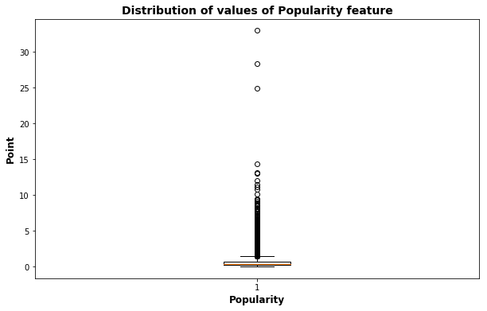

```python
plt.figure(figsize=(10,6))
plt.boxplot(df.popularity);
plt.title('Distribution of values of Popularity feature',fontsize=14,fontweight='bold')
plt.xlabel('Popularity',fontsize=12,fontweight='bold')
plt.ylabel('Point',fontsize=12,fontweight='bold');
```

```python
#From the BoxPlot, it seems that the number of Outliners is very high. Let's have a closer look to find out the number of outliners.
pop_q3 = np.percentile(df.popularity,75)
pop_q1 = np.percentile(df.popularity,25)
pop_iqr = pop_q3 - pop_q1
out_high = pop_q3 + 1.5*pop_iqr
print(out_high)
df_pop_outliners = df[df['popularity'] > out_high]
```

```
1.4731683749999998
```

```python
df_pop_outliners.popularity.describe()
```

```
count    946.000000
mean       2.874282
std        2.226037
min        1.473406
25%        1.769202
50%        2.196241
75%        3.133910
max       32.985763
Name: popularity, dtype: float64
```

#### Since the number of outliners for Popularity is about 10% of the total number of observations, and provided the nature of the movie industry that some movie like Titanic can be popular worldwide, no action will be taken towards the outliners.

## Exploratory Data Analysis

### Research Question 1: Which genres are most popular from year to year?

#### Features like genres and popularity will be studied further as they reflect how popular the genres are. An extract of the original dataframe df will be taken to include these features in the analysis.

```python
# Create the new dataframe df_genres from the original df
df_genres = df.loc[:,['id','original_title','release_year', 'popularity','genres']]
print(df_genres.shape)
df_genres.head(10)
```

```
(10865, 5)
```

|  | id | original_title | release_year | popularity | genres |
| --- | --- | --- | --- | --- | --- |
| 0 | 135397 | Jurassic World | 2015 | 32.985763 | Action\|Adventure\|Science Fiction\|Thriller |
| 1 | 76341 | Mad Max: Fury Road | 2015 | 28.419936 | Action\|Adventure\|Science Fiction\|Thriller |
| 2 | 262500 | Insurgent | 2015 | 13.112507 | Adventure\|Science Fiction\|Thriller |
| 3 | 140607 | Star Wars: The Force Awakens | 2015 | 11.173104 | Action\|Adventure\|Science Fiction\|Fantasy |
| 4 | 168259 | Furious 7 | 2015 | 9.335014 | Action\|Crime\|Thriller |
| 5 | 281957 | The Revenant | 2015 | 9.110700 | Western\|Drama\|Adventure\|Thriller |
| 6 | 87101 | Terminator Genisys | 2015 | 8.654359 | Science Fiction\|Action\|Thriller\|Adventure |
| 7 | 286217 | The Martian | 2015 | 7.667400 | Drama\|Adventure\|Science Fiction |
| 8 | 211672 | Minions | 2015 | 7.404165 | Family\|Animation\|Adventure\|Comedy |
| 9 | 150540 | Inside Out | 2015 | 6.326804 | Comedy\|Animation\|Family |

#### As genres column contains strings with '|' separating different types of genre that the movie follows, the dataframe df_genres will be reshaped to split each genres cell into multiple rows.

```python
# The new indexes of the dataframe will be those columns that are to be remained the same
df_genres.set_index(['id','original_title','release_year', 'popularity'], inplace=True,append=True)
```

```python
df_genres.head()
```

|  | id | original_title | release_year | popularity | genres |
| --- | --- | --- | --- | --- | --- |
| 0 | 135397 | Jurassic World | 2015 | 32.985763 | Action\|Adventure\|Science Fiction\|Thriller |
| 1 | 76341 | Mad Max: Fury Road | 2015 | 28.419936 | Action\|Adventure\|Science Fiction\|Thriller |
| 2 | 262500 | Insurgent | 2015 | 13.112507 | Adventure\|Science Fiction\|Thriller |
| 3 | 140607 | Star Wars: The Force Awakens | 2015 | 11.173104 | Action\|Adventure\|Science Fiction\|Fantasy |
| 4 | 168259 | Furious 7 | 2015 | 9.335014 | Action\|Crime\|Thriller |

```python
#Stack the genres column
df_genres = df_genres.stack()
```

```python
# Split the genres column by delimiter '|', the expand option = True will convert the splitted strings into different columns
df_genres = df_genres.str.split('|',expand=True)
```

```python
#Stack the newly created columns
df_genres = df_genres.stack()
```

```python
# Unstack the 2nd last column, i.e. genres, so that it's moved back into the column level
df_genres = df_genres.unstack(-2)
```

```python
#Remove the index which were created from the string split
df_genres = df_genres.reset_index(-1,drop=True)
```

```python
#Reset the index
df_genres.reset_index(inplace=True)
```

```python
#Drop the level_0 column
df_genres.drop(['level_0'],axis=1,inplace=True)
```

```python
df_genres.head(10)
```

|  | id | original_title | release_year | popularity | genres |
| --- | --- | --- | --- | --- | --- |
| 0 | 135397 | Jurassic World | 2015 | 32.985763 | Action |
| 1 | 135397 | Jurassic World | 2015 | 32.985763 | Adventure |
| 2 | 135397 | Jurassic World | 2015 | 32.985763 | Science Fiction |
| 3 | 135397 | Jurassic World | 2015 | 32.985763 | Thriller |
| 4 | 76341 | Mad Max: Fury Road | 2015 | 28.419936 | Action |
| 5 | 76341 | Mad Max: Fury Road | 2015 | 28.419936 | Adventure |
| 6 | 76341 | Mad Max: Fury Road | 2015 | 28.419936 | Science Fiction |
| 7 | 76341 | Mad Max: Fury Road | 2015 | 28.419936 | Thriller |
| 8 | 262500 | Insurgent | 2015 | 13.112507 | Adventure |
| 9 | 262500 | Insurgent | 2015 | 13.112507 | Science Fiction |

```python
df_genres.info()
```

```
<class 'pandas.core.frame.DataFrame'>
RangeIndex: 26978 entries, 0 to 26977
Data columns (total 5 columns):
id                26978 non-null int64
original_title    26978 non-null object
release_year      26978 non-null int64
popularity        26978 non-null float64
genres            26978 non-null object
dtypes: float64(1), int64(2), object(2)
memory usage: 1.0+ MB
```

```python
#List the unique value of genres
df_genres.genres.unique()
```

```
array(['Action', 'Adventure', 'Science Fiction', 'Thriller', 'Fantasy',
       'Crime', 'Western', 'Drama', 'Family', 'Animation', 'Comedy',
       'Mystery', 'Romance', 'War', 'History', 'Music', 'Horror',
       'Documentary', 'TV Movie', '', 'Foreign'], dtype=object)
```

```python
df_genres.genres.unique().size
```

```
21
```

#### Originally, genres has 10843 non-null values, i.e.(10866 - 10843=23 null values), the following is to verify that the count of '' genre is 23

```python
df_genres.query('genres == ""').count()
```

```
id                23
original_title    23
release_year      23
popularity        23
genres            23
dtype: int64
```

```python
df_genres = df_genres[df_genres['genres'] != ""]
```

```python
df_genres.info()
```

```
<class 'pandas.core.frame.DataFrame'>
Int64Index: 26955 entries, 0 to 26977
Data columns (total 5 columns):
id                26955 non-null int64
original_title    26955 non-null object
release_year      26955 non-null int64
popularity        26955 non-null float64
genres            26955 non-null object
dtypes: float64(1), int64(2), object(2)
memory usage: 1.2+ MB
```

#### Analyse the popularity of each genre thorough the years

```python
genres_pop_avg = df_genres.groupby(['release_year','genres'])['popularity'].mean()
```

```python
genres_pop_avg.head(10)
```

```
release_year  genres
1960          Action       0.590724
              Adventure    0.700981
              Comedy       0.396000
              Crime        0.346480
              Drama        0.566305
              Family       0.278064
              Fantasy      0.428247
              Foreign      0.194948
              History      0.412364
              Horror       0.591450
Name: popularity, dtype: float64
```

```python
genres_pop_avg = genres_pop_avg.unstack(fill_value=0)
```

```python
genres_pop_avg.reset_index(inplace=True)
```

```python
genres_pop_avg.describe()
```

| genres | release_year | Action | Adventure | Animation | Comedy | Crime | Documentary | Drama | Family | Fantasy | ... | History | Horror | Music | Mystery | Romance | Science Fiction | TV Movie | Thriller | War | Western |
| --- | --- | --- | --- | --- | --- | --- | --- | --- | --- | --- | --- | --- | --- | --- | --- | --- | --- | --- | --- | --- | --- |
| count | 56.000000 | 56.000000 | 56.000000 | 56.000000 | 56.000000 | 56.000000 | 56.000000 | 56.000000 | 56.000000 | 56.000000 | ... | 56.000000 | 56.000000 | 56.000000 | 56.000000 | 56.000000 | 56.000000 | 56.000000 | 56.000000 | 56.000000 | 56.000000 |
| mean | 1987.500000 | 0.758278 | 0.937627 | 0.759348 | 0.515554 | 0.643064 | 0.143326 | 0.517394 | 0.687518 | 0.736879 | ... | 0.500318 | 0.428542 | 0.437410 | 0.559890 | 0.514500 | 0.761651 | 0.192995 | 0.633639 | 0.604345 | 0.477775 |
| std | 16.309506 | 0.348455 | 0.454146 | 0.508192 | 0.131579 | 0.262952 | 0.121045 | 0.124962 | 0.275579 | 0.445681 | ... | 0.235346 | 0.158850 | 0.199301 | 0.286616 | 0.145132 | 0.432498 | 0.177632 | 0.214517 | 0.310170 | 0.492506 |
| min | 1960.000000 | 0.241650 | 0.293593 | 0.000000 | 0.270504 | 0.226363 | 0.000000 | 0.305288 | 0.175857 | 0.000000 | ... | 0.000000 | 0.094397 | 0.000000 | 0.000000 | 0.221586 | 0.101956 | 0.000000 | 0.000000 | 0.000000 | 0.000000 |
| 25% | 1973.750000 | 0.577207 | 0.727536 | 0.425591 | 0.437863 | 0.460916 | 0.016456 | 0.425411 | 0.487979 | 0.426081 | ... | 0.335353 | 0.336369 | 0.322184 | 0.324213 | 0.410109 | 0.470920 | 0.000000 | 0.527352 | 0.393568 | 0.241352 |
| 50% | 1987.500000 | 0.718670 | 0.878056 | 0.705948 | 0.505586 | 0.618510 | 0.146335 | 0.522308 | 0.744670 | 0.693653 | ... | 0.517609 | 0.438738 | 0.441273 | 0.561398 | 0.527547 | 0.741162 | 0.174286 | 0.633727 | 0.630816 | 0.366609 |
| 75% | 2001.250000 | 0.889886 | 1.029237 | 1.011112 | 0.598151 | 0.788565 | 0.204898 | 0.579725 | 0.856271 | 0.970919 | ... | 0.654566 | 0.522402 | 0.534301 | 0.709600 | 0.624378 | 0.967813 | 0.308941 | 0.735929 | 0.764093 | 0.601909 |
| max | 2015.000000 | 2.251415 | 3.283786 | 2.631987 | 0.938527 | 1.722032 | 0.521669 | 0.937877 | 1.530722 | 1.829351 | ... | 1.076321 | 0.777631 | 0.968850 | 1.519456 | 0.948865 | 2.294452 | 0.646441 | 1.401877 | 1.481125 | 3.178796 |

8 rows × 21 columns

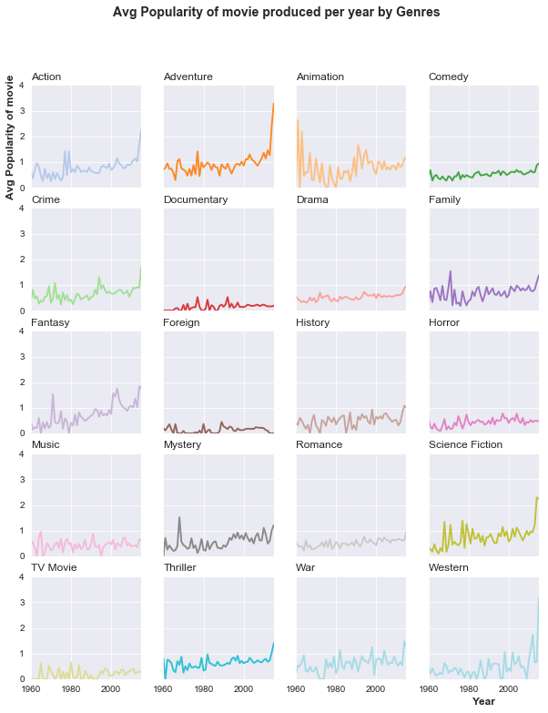

```python
#%config InlineBackend.print_figure_kwargs = {'bbox_inches':None}

# Initialize the figure
sns.set_style('darkgrid')

# create a color palette
palette = plt.get_cmap('tab20')

plt.figure(figsize=(10, 12))

# multiple line plot
num=0
for column in genres_pop_avg.drop('release_year', axis=1):
    num+=1

    # Find the right spot on the plot
    plt.subplot(5,4, num)

    # Plot the lineplot
    plt.plot(genres_pop_avg['release_year'], genres_pop_avg[column], marker='', color=palette(num), linewidth=1.9,
             alpha=0.9, label=column)

    # Same limits for everybody!
    plt.xlim(1960,2015)
    plt.ylim(0,4)

    # Not ticks everywhere
    if num in range(17):
        plt.tick_params(labelbottom=False)
    if num not in [1,5,9,13,17]:
        plt.tick_params(labelleft=False)

    # Add title
    plt.title(column, loc='left', fontsize=12, fontweight=0)

    if num == 1:
        plt.ylabel('Avg Popularity of movie', fontsize=12, fontweight='bold')
    if num == 20:
        plt.xlabel('Year', fontsize=12, fontweight='bold')


# general title
plt.suptitle("Avg Popularity of movie produced per year by Genres", fontsize=14, fontweight='bold')

plt.show()
```

### The diagram shows the popularity of the following genres have been increasing significantly thorough the year:

- Action
- Adventure
- Fantasy
- Science Fiction
- Western

### Research Question 2: What kinds of properties are associated with movies that have high revenues?

#### Features like genres, popularity, vote_average, budget_adj, production_companies, cast and directors will be studied further to analyse how they associate with revenue_adj. An extract of the original dataframe df will be taken to include these features in the analysis.

```python
# Create the new dataframe df_genres from the original df
df_revenue = df.loc[:,['id','original_title', 'popularity', 'vote_average',
                      'budget_adj','revenue_adj','genres','cast','director','production_companies']]
```

```python
df_revenue.info()
```

```
<class 'pandas.core.frame.DataFrame'>
Int64Index: 10865 entries, 0 to 10865
Data columns (total 10 columns):
id                      10865 non-null int64
original_title          10865 non-null object
popularity              10865 non-null float64
vote_average            10865 non-null float64
budget_adj              10865 non-null float64
revenue_adj             10865 non-null float64
genres                  10865 non-null object
cast                    10865 non-null object
director                10865 non-null object
production_companies    10865 non-null object
dtypes: float64(4), int64(1), object(5)
memory usage: 933.7+ KB
```

```python
df_revenue.revenue_adj.describe()
```

[output not shown]

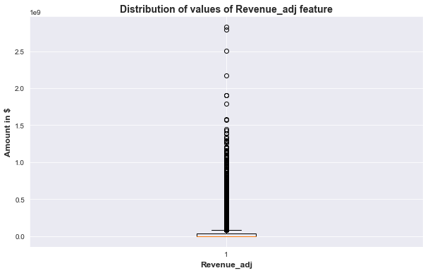

```python
plt.figure(figsize=(10,6))
plt.boxplot(df_revenue.revenue_adj);
plt.title('Distribution of values of Revenue_adj feature',fontsize=14,fontweight='bold')
plt.xlabel('Revenue_adj',fontsize=12,fontweight='bold')
plt.ylabel('Amount in $',fontsize=12,fontweight='bold');
```

```python
df_high_revenue = df_revenue[df_revenue.revenue_adj > np.percentile(df_revenue.revenue_adj,75)]
```

```python
df_high_revenue.describe()
```

|  | id | popularity | vote_average | budget_adj | revenue_adj |
| --- | --- | --- | --- | --- | --- |
| count | 2716.000000 | 2716.000000 | 2716.000000 | 2.716000e+03 | 2.716000e+03 |
| mean | 32552.220177 | 1.431496 | 6.268189 | 5.275974e+07 | 1.969987e+08 |
| std | 61024.096342 | 1.664589 | 0.750178 | 4.883008e+07 | 2.351033e+08 |
| min | 11.000000 | 0.010335 | 3.400000 | 0.000000e+00 | 3.373181e+07 |
| 25% | 2881.500000 | 0.595218 | 5.800000 | 1.810451e+07 | 6.379738e+07 |
| 50% | 10196.500000 | 1.011454 | 6.300000 | 3.838161e+07 | 1.125519e+08 |
| 75% | 22602.000000 | 1.662845 | 6.800000 | 7.503209e+07 | 2.298801e+08 |
| max | 417859.000000 | 32.985763 | 8.400000 | 3.683713e+08 | 2.827124e+09 |

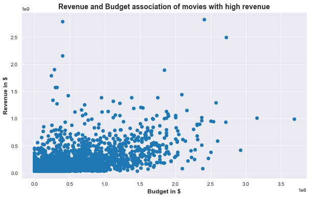

```python
plt.figure(figsize=(10,6))
plt.scatter(df_high_revenue.budget_adj, df_high_revenue.revenue_adj);
plt.title('Revenue and Budget association of movies with high revenue',fontsize=14,fontweight='bold')
plt.xlabel('Budget in $',fontsize=12,fontweight='bold')
plt.ylabel('Revenue in $',fontsize=12,fontweight='bold');
```

#### Revenue_adj feature does not associate with budget_adj very well. Multiple movies with high revenue_adj have low budget_adj.

[figure not shown]

```python
plt.figure(figsize=(10,6))
plt.scatter(df_high_revenue.budget_adj, df_high_revenue.popularity);
plt.title('Revenue and Popularity association of movies with high revenues',fontsize=14,fontweight='bold')
plt.xlabel('Popularity point',fontsize=12,fontweight='bold')
plt.ylabel('Revenue in $',fontsize=12,fontweight='bold');
```

[figure not shown]

```python
plt.figure(figsize=(10,6))
plt.scatter(df_high_revenue.vote_average, df_high_revenue.popularity);
plt.title('Revenue and Average Vote association of movies with high revenues',fontsize=14,fontweight='bold')
plt.xlabel('Average Vote',fontsize=12,fontweight='bold')
plt.ylabel('Revenue in $',fontsize=12,fontweight='bold');
```

```python
df_high_revenue.nlargest(20,'revenue_adj')
```

|  | id | original_title | popularity | vote_average | budget_adj | revenue_adj | genres | cast | director | production_companies |
| --- | --- | --- | --- | --- | --- | --- | --- | --- | --- | --- |
| 1386 | 19995 | Avatar | 9.432768 | 7.1 | 2.408869e+08 | 2.827124e+09 | Action\|Adventure\|Fantasy\|Science Fiction | Sam Worthington\|Zoe Saldana\|Sigourney Weaver\|S... | James Cameron | Ingenious Film Partners\|Twentieth Century Fox ... |
| 1329 | 11 | Star Wars | 12.037933 | 7.9 | 3.957559e+07 | 2.789712e+09 | Adventure\|Action\|Science Fiction | Mark Hamill\|Harrison Ford\|Carrie Fisher\|Peter ... | George Lucas | Lucasfilm\|Twentieth Century Fox Film Corporation |
| 5231 | 597 | Titanic | 4.355219 | 7.3 | 2.716921e+08 | 2.506406e+09 | Drama\|Romance\|Thriller | Kate Winslet\|Leonardo DiCaprio\|Frances Fisher\|... | James Cameron | Paramount Pictures\|Twentieth Century Fox Film ... |
| 10594 | 9552 | The Exorcist | 2.010733 | 7.2 | 3.928928e+07 | 2.167325e+09 | Drama\|Horror\|Thriller | Linda Blair\|Max von Sydow\|Ellen Burstyn\|Jason ... | William Friedkin | Warner Bros.\|Hoya Productions |
| 9806 | 578 | Jaws | 2.563191 | 7.3 | 2.836275e+07 | 1.907006e+09 | Horror\|Thriller\|Adventure | Roy Scheider\|Robert Shaw\|Richard Dreyfuss\|Lorr... | Steven Spielberg | Universal Pictures\|Zanuck/Brown Productions |
| 3 | 140607 | Star Wars: The Force Awakens | 11.173104 | 7.5 | 1.839999e+08 | 1.902723e+09 | Action\|Adventure\|Science Fiction\|Fantasy | Harrison Ford\|Mark Hamill\|Carrie Fisher\|Adam D... | J.J. Abrams | Lucasfilm\|Truenorth Productions\|Bad Robot |
| 8889 | 601 | E.T. the Extra-Terrestrial | 2.900556 | 7.2 | 2.372625e+07 | 1.791694e+09 | Science Fiction\|Adventure\|Family\|Fantasy | Henry Thomas\|Drew Barrymore\|Robert MacNaughton... | Steven Spielberg | Universal Pictures\|Amblin Entertainment |
| 8094 | 1642 | The Net | 1.136610 | 5.6 | 3.148127e+07 | 1.583050e+09 | Crime\|Drama\|Mystery\|Thriller\|Action | Sandra Bullock\|Jeremy Northam\|Dennis Miller\|We... | Irwin Winkler | Columbia Pictures |
| 10110 | 12230 | One Hundred and One Dalmatians | 2.631987 | 6.6 | 2.917944e+07 | 1.574815e+09 | Adventure\|Animation\|Comedy\|Family | Rod Taylor\|J. Pat O'Malley\|Betty Lou Gerson\|Ma... | Clyde Geronimi\|Hamilton Luske\|Wolfgang Reitherman | Walt Disney Productions |
| 4361 | 24428 | The Avengers | 7.637767 | 7.3 | 2.089437e+08 | 1.443191e+09 | Science Fiction\|Action\|Adventure | Robert Downey Jr.\|Chris Evans\|Mark Ruffalo\|Chr... | Joss Whedon | Marvel Studios |
| 7309 | 1891 | The Empire Strikes Back | 5.488441 | 8.0 | 4.762866e+07 | 1.424626e+09 | Adventure\|Action\|Science Fiction | Mark Hamill\|Harrison Ford\|Carrie Fisher\|Billy ... | Irvin Kershner | Lucasfilm\|Twentieth Century Fox Film Corporation |
| 0 | 135397 | Jurassic World | 32.985763 | 6.5 | 1.379999e+08 | 1.392446e+09 | Action\|Adventure\|Science Fiction\|Thriller | Chris Pratt\|Bryce Dallas Howard\|Irrfan Khan\|Vi... | Colin Trevorrow | Universal Studios\|Amblin Entertainment\|Legenda... |
| 10223 | 329 | Jurassic Park | 2.204926 | 7.4 | 9.509661e+07 | 1.388863e+09 | Adventure\|Science Fiction | Sam Neill\|Laura Dern\|Jeff Goldblum\|Richard Att... | Steven Spielberg | Universal Pictures\|Amblin Entertainment |
| 4 | 168259 | Furious 7 | 9.335014 | 7.3 | 1.747999e+08 | 1.385749e+09 | Action\|Crime\|Thriller | Vin Diesel\|Paul Walker\|Jason Statham\|Michelle ... | James Wan | Universal Pictures\|Original Film\|Media Rights ... |
| 10398 | 9325 | The Jungle Book | 2.550704 | 7.0 | 2.614705e+07 | 1.345551e+09 | Family\|Animation\|Adventure | Phil Harris\|Sebastian Cabot\|Louis Prima\|George... | Wolfgang Reitherman | Walt Disney Pictures |
| 4949 | 122 | The Lord of the Rings: The Return of the King | 7.122455 | 7.9 | 1.114231e+08 | 1.326278e+09 | Adventure\|Fantasy\|Action | Elijah Wood\|Ian McKellen\|Viggo Mortensen\|Liv T... | Peter Jackson | WingNut Films\|New Line Cinema |
| 14 | 99861 | Avengers: Age of Ultron | 5.944927 | 7.4 | 2.575999e+08 | 1.292632e+09 | Action\|Adventure\|Science Fiction | Robert Downey Jr.\|Chris Hemsworth\|Mark Ruffalo... | Joss Whedon | Marvel Studios\|Prime Focus\|Revolution Sun Studios |
| 3374 | 12445 | Harry Potter and the Deathly Hallows: Part 2 | 5.711315 | 7.7 | 1.211748e+08 | 1.287184e+09 | Adventure\|Family\|Fantasy | Daniel Radcliffe\|Rupert Grint\|Emma Watson\|Alan... | David Yates | Warner Bros.\|Heyday Films\|Moving Picture Compa... |
| 7269 | 238 | The Godfather | 5.738034 | 8.3 | 3.128737e+07 | 1.277914e+09 | Drama\|Crime | Marlon Brando\|Al Pacino\|James Caan\|Richard S. ... | Francis Ford Coppola | Paramount Pictures\|Alfran Productions |
| 7987 | 1892 | Return of the Jedi | 4.828854 | 7.8 | 7.082424e+07 | 1.253819e+09 | Adventure\|Action\|Science Fiction | Mark Hamill\|Harrison Ford\|Carrie Fisher\|Billy ... | Richard Marquand | Lucasfilm\|Twentieth Century Fox Film Corporation |

#### From the above table, James Cameron and Steven Speilberg directed few movies which generate very high revenue_adj. Few genres such as Action, Science Action and Adventure appear frequently among the top revenue_adj movies. Similarly, production companies including Century Fox Film Corporation and Universal Pictures appear frequently too. Hence, will analyse the association between revenue_adj and director, genres and production_companies feature.

```python
df_high_revenue.set_index(['id','original_title','popularity','vote_average','budget_adj', 'revenue_adj',
                    'genres','cast','production_companies'], inplace=True,append=True)
df_high_revenue.head()
```

|  | id | original_title | popularity | vote_average | budget_adj | revenue_adj | genres | cast | production_companies | director |
| --- | --- | --- | --- | --- | --- | --- | --- | --- | --- | --- |
| 0 | 135397 | Jurassic World | 32.985763 | 6.5 | 1.379999e+08 | 1.392446e+09 | Action\|Adventure\|Science Fiction\|Thriller | Chris Pratt\|Bryce Dallas Howard\|Irrfan Khan\|Vincent D'Onofrio\|Nick Robinson | Universal Studios\|Amblin Entertainment\|Legendary Pictures\|Fuji Television Network\|Dentsu | Colin Trevorrow |
| 1 | 76341 | Mad Max: Fury Road | 28.419936 | 7.1 | 1.379999e+08 | 3.481613e+08 | Action\|Adventure\|Science Fiction\|Thriller | Tom Hardy\|Charlize Theron\|Hugh Keays-Byrne\|Nicholas Hoult\|Josh Helman | Village Roadshow Pictures\|Kennedy Miller Productions | George Miller |
| 2 | 262500 | Insurgent | 13.112507 | 6.3 | 1.012000e+08 | 2.716190e+08 | Adventure\|Science Fiction\|Thriller | Shailene Woodley\|Theo James\|Kate Winslet\|Ansel Elgort\|Miles Teller | Summit Entertainment\|Mandeville Films\|Red Wagon Entertainment\|NeoReel | Robert Schwentke |
| 3 | 140607 | Star Wars: The Force Awakens | 11.173104 | 7.5 | 1.839999e+08 | 1.902723e+09 | Action\|Adventure\|Science Fiction\|Fantasy | Harrison Ford\|Mark Hamill\|Carrie Fisher\|Adam Driver\|Daisy Ridley | Lucasfilm\|Truenorth Productions\|Bad Robot | J.J. Abrams |
| 4 | 168259 | Furious 7 | 9.335014 | 7.3 | 1.747999e+08 | 1.385749e+09 | Action\|Crime\|Thriller | Vin Diesel\|Paul Walker\|Jason Statham\|Michelle Rodriguez\|Dwayne Johnson | Universal Pictures\|Original Film\|Media Rights Capital\|Dentsu\|One Race Films | James Wan |

```python
df_high_revenue = df_high_revenue.stack()
```

```python
df_high_revenue = df_high_revenue.str.split('|',expand=True)
```

```python
df_high_revenue = df_high_revenue.stack()
```

```python
df_high_revenue = df_high_revenue.unstack(-2)
```

```python
#Remove the index which were created from the string split
df_high_revenue = df_high_revenue.reset_index(-1,drop=True)
```

```python
#Reset the index
df_high_revenue.reset_index(inplace=True)
```

```python
#Drop the level_0 column
df_high_revenue.drop(['level_0'],axis=1,inplace=True)
```

```python
df_high_revenue.head(20)
```

|  | id | original_title | popularity | vote_average | budget_adj | revenue_adj | genres | cast | production_companies | director |
| --- | --- | --- | --- | --- | --- | --- | --- | --- | --- | --- |
| 0 | 135397 | Jurassic World | 32.985763 | 6.5 | 1.379999e+08 | 1.392446e+09 | Action\|Adventure\|Science Fiction\|Thriller | Chris Pratt\|Bryce Dallas Howard\|Irrfan Khan\|Vi... | Universal Studios\|Amblin Entertainment\|Legenda... | Colin Trevorrow |
| 1 | 76341 | Mad Max: Fury Road | 28.419936 | 7.1 | 1.379999e+08 | 3.481613e+08 | Action\|Adventure\|Science Fiction\|Thriller | Tom Hardy\|Charlize Theron\|Hugh Keays-Byrne\|Nic... | Village Roadshow Pictures\|Kennedy Miller Produ... | George Miller |
| 2 | 262500 | Insurgent | 13.112507 | 6.3 | 1.012000e+08 | 2.716190e+08 | Adventure\|Science Fiction\|Thriller | Shailene Woodley\|Theo James\|Kate Winslet\|Ansel... | Summit Entertainment\|Mandeville Films\|Red Wago... | Robert Schwentke |
| 3 | 140607 | Star Wars: The Force Awakens | 11.173104 | 7.5 | 1.839999e+08 | 1.902723e+09 | Action\|Adventure\|Science Fiction\|Fantasy | Harrison Ford\|Mark Hamill\|Carrie Fisher\|Adam D... | Lucasfilm\|Truenorth Productions\|Bad Robot | J.J. Abrams |
| 4 | 168259 | Furious 7 | 9.335014 | 7.3 | 1.747999e+08 | 1.385749e+09 | Action\|Crime\|Thriller | Vin Diesel\|Paul Walker\|Jason Statham\|Michelle ... | Universal Pictures\|Original Film\|Media Rights ... | James Wan |
| 5 | 281957 | The Revenant | 9.110700 | 7.2 | 1.241999e+08 | 4.903142e+08 | Western\|Drama\|Adventure\|Thriller | Leonardo DiCaprio\|Tom Hardy\|Will Poulter\|Domhn... | Regency Enterprises\|Appian Way\|CatchPlay\|Anony... | Alejandro González Iñárritu |
| 6 | 87101 | Terminator Genisys | 8.654359 | 5.8 | 1.425999e+08 | 4.053551e+08 | Science Fiction\|Action\|Thriller\|Adventure | Arnold Schwarzenegger\|Jason Clarke\|Emilia Clar... | Paramount Pictures\|Skydance Productions | Alan Taylor |
| 7 | 286217 | The Martian | 7.667400 | 7.6 | 9.935996e+07 | 5.477497e+08 | Drama\|Adventure\|Science Fiction | Matt Damon\|Jessica Chastain\|Kristen Wiig\|Jeff ... | Twentieth Century Fox Film Corporation\|Scott F... | Ridley Scott |
| 8 | 211672 | Minions | 7.404165 | 6.5 | 6.807997e+07 | 1.064192e+09 | Family\|Animation\|Adventure\|Comedy | Sandra Bullock\|Jon Hamm\|Michael Keaton\|Allison... | Universal Pictures\|Illumination Entertainment | Kyle Balda |
| 9 | 211672 | Minions | 7.404165 | 6.5 | 6.807997e+07 | 1.064192e+09 | Family\|Animation\|Adventure\|Comedy | Sandra Bullock\|Jon Hamm\|Michael Keaton\|Allison... | Universal Pictures\|Illumination Entertainment | Pierre Coffin |
| 10 | 150540 | Inside Out | 6.326804 | 8.0 | 1.609999e+08 | 7.854116e+08 | Comedy\|Animation\|Family | Amy Poehler\|Phyllis Smith\|Richard Kind\|Bill Ha... | Walt Disney Pictures\|Pixar Animation Studios\|W... | Pete Docter |
| 11 | 206647 | Spectre | 6.200282 | 6.2 | 2.253999e+08 | 8.102203e+08 | Action\|Adventure\|Crime | Daniel Craig\|Christoph Waltz\|Léa Seydoux\|Ralp... | Columbia Pictures\|Danjaq\|B24 | Sam Mendes |
| 12 | 76757 | Jupiter Ascending | 6.189369 | 5.2 | 1.619199e+08 | 1.692686e+08 | Science Fiction\|Fantasy\|Action\|Adventure | Mila Kunis\|Channing Tatum\|Sean Bean\|Eddie Redm... | Village Roadshow Pictures\|Dune Entertainment\|A... | Lana Wachowski |
| 13 | 76757 | Jupiter Ascending | 6.189369 | 5.2 | 1.619199e+08 | 1.692686e+08 | Science Fiction\|Fantasy\|Action\|Adventure | Mila Kunis\|Channing Tatum\|Sean Bean\|Eddie Redm... | Village Roadshow Pictures\|Dune Entertainment\|A... | Lilly Wachowski |
| 14 | 257344 | Pixels | 5.984995 | 5.8 | 8.095996e+07 | 2.241460e+08 | Action\|Comedy\|Science Fiction | Adam Sandler\|Michelle Monaghan\|Peter Dinklage\|... | Columbia Pictures\|Happy Madison Productions | Chris Columbus |
| 15 | 99861 | Avengers: Age of Ultron | 5.944927 | 7.4 | 2.575999e+08 | 1.292632e+09 | Action\|Adventure\|Science Fiction | Robert Downey Jr.\|Chris Hemsworth\|Mark Ruffalo... | Marvel Studios\|Prime Focus\|Revolution Sun Studios | Joss Whedon |
| 16 | 273248 | The Hateful Eight | 5.898400 | 7.4 | 4.047998e+07 | 1.432992e+08 | Crime\|Drama\|Mystery\|Western | Samuel L. Jackson\|Kurt Russell\|Jennifer Jason ... | Double Feature Films\|The Weinstein Company\|Fil... | Quentin Tarantino |
| 17 | 260346 | Taken 3 | 5.749758 | 6.1 | 4.415998e+07 | 2.997096e+08 | Crime\|Action\|Thriller | Liam Neeson\|Forest Whitaker\|Maggie Grace\|Famke... | Twentieth Century Fox Film Corporation\|M6 Film... | Olivier Megaton |
| 18 | 102899 | Ant-Man | 5.573184 | 7.0 | 1.195999e+08 | 4.771138e+08 | Science Fiction\|Action\|Adventure | Paul Rudd\|Michael Douglas\|Evangeline Lilly\|Cor... | Marvel Studios | Peyton Reed |
| 19 | 150689 | Cinderella | 5.556818 | 6.8 | 8.739996e+07 | 4.989630e+08 | Romance\|Fantasy\|Family\|Drama | Lily James\|Cate Blanchett\|Richard Madden\|Helen... | Walt Disney Pictures\|Genre Films\|Beagle Pug Fi... | Kenneth Branagh |

```python
df_high_revenue.shape
```

```
(2451, 10)
```

```python
df_high_revenue.director.unique().size
```

```
998
```

```python
high_revenue_directors = df_high_revenue.groupby('director')['id'].count()
```

```python
high_revenue_directors.nlargest(50)
```

```
director
Steven Spielberg        28
Clint Eastwood          24
Ridley Scott            17
Ron Howard              17
Tim Burton              15
Robert Zemeckis         14
Joel Schumacher         13
Martin Scorsese         12
Ivan Reitman            11
Michael Bay             11
Tony Scott              11
Brian De Palma          10
Chris Columbus          10
David Fincher           10
Francis Ford Coppola    10
Oliver Stone            10
Richard Donner          10
Woody Allen             10
Brett Ratner             9
Dennis Dugan             9
George Miller            9
Mike Nichols             9
Peter Farrelly           9
Raja Gosnell             9
Rob Reiner               9
Steven Soderbergh        9
Sydney Pollack           9
Barry Levinson           8
Barry Sonnenfeld         8
Blake Edwards            8
Bobby Farrelly           8
Edward Zwick             8
Garry Marshall           8
Gore Verbinski           8
Jon Turteltaub           8
M. Night Shyamalan       8
Paul W.S. Anderson       8
Peter Jackson            8
Quentin Tarantino        8
Renny Harlin             8
Robert Rodriguez         8
Roland Emmerich          8
Shawn Levy               8
Stanley Kubrick          8
Adam Shankman            7
Antoine Fuqua            7
Christopher Nolan        7
F. Gary Gray             7
Frank Coraci             7
James Cameron            7
Name: id, dtype: int64
```

```python
high_revenue_directors.nsmallest(10)
```

```
director
A.R. Murugadoss        1
Adam Brooks            1
Akiva Schaffer         1
Alan Metter            1
Alan Myerson           1
Alan Poul              1
Alastair Fothergill    1
Alejandro Agresti      1
Alejandro AmenÃ¡bar    1
Aleksander Bach        1
Name: id, dtype: int64
```

### The lists above shows 50 directors who have the highest count of high revenue movies, and 10 directors who have the lowest count of high revenue movies. Top of the list are Steven Spielberg with 28 movies and followed by Clint Eastwood with 24 movies; while all the 10 directors in the 2nd list have 1 movie. Hence, there is an association between the directors and movie revenue.

#### Now will analyse the association between revenue and the cast feature.

#### First, will need to remove the duplicate rows created from splitting the director feature.

```python
df_high_revenue.drop_duplicates(subset='id',inplace=True)
```

```python
#Drop the director, popularity,vote_average, budget_adj features in df_high_revenue as we've no longer need to analyse them
df_high_revenue.drop(['director','popularity','vote_average','budget_adj'],axis=1,inplace=True)
df_high_revenue.shape
```

```
(2261, 6)
```

```python
df_high_revenue.head()
```

|  | id | original_title | revenue_adj | genres | cast | production_companies |
| --- | --- | --- | --- | --- | --- | --- |
| 0 | 135397 | Jurassic World | 1.392446e+09 | Action\|Adventure\|Science Fiction\|Thriller | Chris Pratt\|Bryce Dallas Howard\|Irrfan Khan\|Vi... | Universal Studios\|Amblin Entertainment\|Legenda... |
| 1 | 76341 | Mad Max: Fury Road | 3.481613e+08 | Action\|Adventure\|Science Fiction\|Thriller | Tom Hardy\|Charlize Theron\|Hugh Keays-Byrne\|Nic... | Village Roadshow Pictures\|Kennedy Miller Produ... |
| 2 | 262500 | Insurgent | 2.716190e+08 | Adventure\|Science Fiction\|Thriller | Shailene Woodley\|Theo James\|Kate Winslet\|Ansel... | Summit Entertainment\|Mandeville Films\|Red Wago... |
| 3 | 140607 | Star Wars: The Force Awakens | 1.902723e+09 | Action\|Adventure\|Science Fiction\|Fantasy | Harrison Ford\|Mark Hamill\|Carrie Fisher\|Adam D... | Lucasfilm\|Truenorth Productions\|Bad Robot |
| 4 | 168259 | Furious 7 | 1.385749e+09 | Action\|Crime\|Thriller | Vin Diesel\|Paul Walker\|Jason Statham\|Michelle ... | Universal Pictures\|Original Film\|Media Rights ... |

#### Split the cast feature by '|' delimiter

```python
df_high_revenue.set_index(['id','original_title','revenue_adj','genres','production_companies'],inplace=True,append=True)
```

```python
df_high_revenue.head()
```

|  | id | original_title | revenue_adj | genres | production_companies | cast |
| --- | --- | --- | --- | --- | --- | --- |
| 0 | 135397 | Jurassic World | 1.392446e+09 | Action\|Adventure\|Science Fiction\|Thriller | Universal Studios\|Amblin Entertainment\|Legendary Pictures\|Fuji Television Network\|Dentsu | Chris Pratt\|Bryce Dallas Howard\|Irrfan Khan\|Vi... |
| 1 | 76341 | Mad Max: Fury Road | 3.481613e+08 | Action\|Adventure\|Science Fiction\|Thriller | Village Roadshow Pictures\|Kennedy Miller Productions | Tom Hardy\|Charlize Theron\|Hugh Keays-Byrne\|Nic... |
| 2 | 262500 | Insurgent | 2.716190e+08 | Adventure\|Science Fiction\|Thriller | Summit Entertainment\|Mandeville Films\|Red Wagon Entertainment\|NeoReel | Shailene Woodley\|Theo James\|Kate Winslet\|Ansel... |
| 3 | 140607 | Star Wars: The Force Awakens | 1.902723e+09 | Action\|Adventure\|Science Fiction\|Fantasy | Lucasfilm\|Truenorth Productions\|Bad Robot | Harrison Ford\|Mark Hamill\|Carrie Fisher\|Adam D... |
| 4 | 168259 | Furious 7 | 1.385749e+09 | Action\|Crime\|Thriller | Universal Pictures\|Original Film\|Media Rights Capital\|Dentsu\|One Race Films | Vin Diesel\|Paul Walker\|Jason Statham\|Michelle ... |

```python
df_high_revenue = df_high_revenue.stack()
```

```python
df_high_revenue = df_high_revenue.str.split('|',expand=True)
```

```python
df_high_revenue = df_high_revenue.stack()
```

```python
df_high_revenue = df_high_revenue.unstack(-2)
```

```python
df_high_revenue = df_high_revenue.reset_index(-1,drop=True)
```

```python
df_high_revenue.reset_index(inplace=True)
```

```python
df_high_revenue.drop(['level_0'],axis=1,inplace=True)
```

```python
df_high_revenue.head(10)
```

|  | id | original_title | revenue_adj | genres | production_companies | cast |
| --- | --- | --- | --- | --- | --- | --- |
| 0 | 135397 | Jurassic World | 1.392446e+09 | Action\|Adventure\|Science Fiction\|Thriller | Universal Studios\|Amblin Entertainment\|Legenda... | Chris Pratt |
| 1 | 135397 | Jurassic World | 1.392446e+09 | Action\|Adventure\|Science Fiction\|Thriller | Universal Studios\|Amblin Entertainment\|Legenda... | Bryce Dallas Howard |
| 2 | 135397 | Jurassic World | 1.392446e+09 | Action\|Adventure\|Science Fiction\|Thriller | Universal Studios\|Amblin Entertainment\|Legenda... | Irrfan Khan |
| 3 | 135397 | Jurassic World | 1.392446e+09 | Action\|Adventure\|Science Fiction\|Thriller | Universal Studios\|Amblin Entertainment\|Legenda... | Vincent D'Onofrio |
| 4 | 135397 | Jurassic World | 1.392446e+09 | Action\|Adventure\|Science Fiction\|Thriller | Universal Studios\|Amblin Entertainment\|Legenda... | Nick Robinson |
| 5 | 76341 | Mad Max: Fury Road | 3.481613e+08 | Action\|Adventure\|Science Fiction\|Thriller | Village Roadshow Pictures\|Kennedy Miller Produ... | Tom Hardy |
| 6 | 76341 | Mad Max: Fury Road | 3.481613e+08 | Action\|Adventure\|Science Fiction\|Thriller | Village Roadshow Pictures\|Kennedy Miller Produ... | Charlize Theron |
| 7 | 76341 | Mad Max: Fury Road | 3.481613e+08 | Action\|Adventure\|Science Fiction\|Thriller | Village Roadshow Pictures\|Kennedy Miller Produ... | Hugh Keays-Byrne |
| 8 | 76341 | Mad Max: Fury Road | 3.481613e+08 | Action\|Adventure\|Science Fiction\|Thriller | Village Roadshow Pictures\|Kennedy Miller Produ... | Nicholas Hoult |
| 9 | 76341 | Mad Max: Fury Road | 3.481613e+08 | Action\|Adventure\|Science Fiction\|Thriller | Village Roadshow Pictures\|Kennedy Miller Produ... | Josh Helman |

```python
high_revenue_cast = df_high_revenue.groupby('cast')['id'].count()
```

```python
high_revenue_cast.nlargest(50)
```

```
cast
Robert De Niro           37
Bruce Willis             34
Tom Cruise               32
Tom Hanks                32
Brad Pitt                29
Robin Williams           29
Samuel L. Jackson        28
Eddie Murphy             27
Harrison Ford            27
Nicolas Cage             27
Sylvester Stallone       27
Johnny Depp              26
Arnold Schwarzenegger    25
Cameron Diaz             25
Clint Eastwood           25
Denzel Washington        25
Morgan Freeman           25
John Travolta            24
Matt Damon               24
Adam Sandler             23
Mark Wahlberg            23
Dustin Hoffman           22
Gene Hackman             22
George Clooney           22
Julia Roberts            22
Meryl Streep             22
Al Pacino                21
Jim Carrey               21
Mel Gibson               21
Michael Douglas          21
Sandra Bullock           21
Ben Stiller              20
Liam Neeson              20
Owen Wilson              20
Robert Duvall            20
Keanu Reeves             19
Michael Caine            19
Angelina Jolie           18
Dwayne Johnson           18
John Goodman             18
Robert Downey Jr.        18
Sean Connery             18
Will Smith               18
Alec Baldwin             17
Gary Oldman              17
Jeff Bridges             17
Leonardo DiCaprio        17
Ralph Fiennes            17
Steve Carell             17
Will Ferrell             17
Name: id, dtype: int64
```

```python
high_revenue_cast.nsmallest(10)
```

```
cast
A.J. Cook           1
Aaran Thomas        1
Aaron Ruell         1
Aaron Stanford      1
Aasif Mandvi        1
Abigail Hargrove    1
Adam Alexi-Malle    1
Adam Arkin          1
Adam Brody          1
Adam Driver         1
Name: id, dtype: int64
```

### The lists above shows 50 actors who have the highest count of high revenue movies, and 10 actors who have the lowest count of high revenue movies. Top of the list are Robert De Niro with 37 movies and followed by Bruce Willis with 34 movies; while all the 10 actors in the 2nd list have 1 movie. Hence, there is an association between the actors and movie revenue.

#### Now will analyse the association between revenue and the production_companies feature.

#### First, will need to remove the duplicate rows created from splitting the cast feature previously.

```python
df_high_revenue.drop_duplicates(subset='id',inplace=True)
```

```python
#Drop cast column from the dataframe df_high_revenue as we no longer need to analyse it
df_high_revenue.drop(['cast'],axis=1,inplace=True)
```

```python
df_high_revenue.head()
```

|  | id | original_title | revenue_adj | genres | production_companies |
| --- | --- | --- | --- | --- | --- |
| 0 | 135397 | Jurassic World | 1.392446e+09 | Action\|Adventure\|Science Fiction\|Thriller | Universal Studios\|Amblin Entertainment\|Legenda... |
| 5 | 76341 | Mad Max: Fury Road | 3.481613e+08 | Action\|Adventure\|Science Fiction\|Thriller | Village Roadshow Pictures\|Kennedy Miller Produ... |
| 10 | 262500 | Insurgent | 2.716190e+08 | Adventure\|Science Fiction\|Thriller | Summit Entertainment\|Mandeville Films\|Red Wago... |
| 15 | 140607 | Star Wars: The Force Awakens | 1.902723e+09 | Action\|Adventure\|Science Fiction\|Fantasy | Lucasfilm\|Truenorth Productions\|Bad Robot |
| 20 | 168259 | Furious 7 | 1.385749e+09 | Action\|Crime\|Thriller | Universal Pictures\|Original Film\|Media Rights ... |

#### Split the production_companies feature by '|' delimiter

```python
df_high_revenue.set_index(['id','original_title','revenue_adj','genres'],inplace=True,append=True)
```

```python
df_high_revenue = df_high_revenue.stack()
```

```python
df_high_revenue = df_high_revenue.str.split('|',expand=True)
```

```python
df_high_revenue = df_high_revenue.stack()
```

```python
df_high_revenue = df_high_revenue.unstack(-2)
```

```python
#Remove the index which were created from the string split
df_high_revenue = df_high_revenue.reset_index(-1,drop=True)
```

```python
#Reset the index
df_high_revenue.reset_index(inplace=True)
```

```python
df_high_revenue.drop(['level_0'],axis=1,inplace=True)
```

```python
high_revenue_production_companies = df_high_revenue.groupby(['production_companies'])['id'].count()
```

```python
high_revenue_production_companies.nlargest(50)
```

```
production_companies
Warner Bros.                              270
Universal Pictures                        265
Paramount Pictures                        219
Twentieth Century Fox Film Corporation    172
Columbia Pictures                         150
Walt Disney Pictures                      103
New Line Cinema                            99
Touchstone Pictures                        89
Columbia Pictures Corporation              79
Metro-Goldwyn-Mayer (MGM)                  75
Relativity Media                           69
Village Roadshow Pictures                  63
DreamWorks SKG                             61
Amblin Entertainment                       55
Regency Enterprises                        52
TriStar Pictures                           42
Fox 2000 Pictures                          39
United Artists                             39
Dune Entertainment                         38
Legendary Pictures                         32
Miramax Films                              31
Silver Pictures                            31
Working Title Films                        31
Imagine Entertainment                      30
Spyglass Entertainment                     30
DreamWorks Animation                       28
Original Film                              28
20th Century Fox                           24
Dimension Films                            24
Orion Pictures                             24
Scott Rudin Productions                    24
Summit Entertainment                       24
Davis Entertainment                        23
Happy Madison Productions                  23
Eon Productions                            22
Jerry Bruckheimer Films                    22
New Regency Pictures                       22
Revolution Studios                         22
Canal+                                     21
Castle Rock Entertainment                  21
Malpaso Productions                        21
Lionsgate                                  20
Scott Free Productions                     20
Studio Babelsberg                          20
StudioCanal                                19
Screen Gems                                18
Apatow Productions                         16
NPV Entertainment                          16
Pixar Animation Studios                    16
Focus Features                             15
Name: id, dtype: int64
```

```python
high_revenue_production_companies.nsmallest(10)
```

```
production_companies
"DIA" Productions GmbH & Co. KG        1
11:11 Mediaworks                       1
1984 Private Defense Contractors       1
20th Century Fox Home Entertainment    1
20th Century Fox Russia                1
20th Century Fox Television            1
26 Films                               1
2929 Productions                       1
2S Films                               1
3Foot7                                 1
Name: id, dtype: int64
```

### The lists above shows 50 production companies which have the highest count of high revenue movies, and 10 companies which have the lowest count of high revenue movies. Top of the list are Warner Bros. with 270 movies and Universal Pictures with 265 movies; while all the 10 companies in the 2nd list have 1 movie. Hence, there is an association between the production companies and movie revenue.

#### Now will analyse the association between revenue and the genres feature.

```python
df_high_revenue.drop_duplicates(subset='id',inplace=True)
```

```python
#Drop production_companies as we no long need to analyse it
df_high_revenue.drop(['production_companies'],axis=1,inplace=True)
```

```python
df_high_revenue.head()
```

|  | id | original_title | revenue_adj | genres |
| --- | --- | --- | --- | --- |
| 0 | 135397 | Jurassic World | 1.392446e+09 | Action\|Adventure\|Science Fiction\|Thriller |
| 5 | 76341 | Mad Max: Fury Road | 3.481613e+08 | Action\|Adventure\|Science Fiction\|Thriller |
| 7 | 262500 | Insurgent | 2.716190e+08 | Adventure\|Science Fiction\|Thriller |
| 11 | 140607 | Star Wars: The Force Awakens | 1.902723e+09 | Action\|Adventure\|Science Fiction\|Fantasy |
| 14 | 168259 | Furious 7 | 1.385749e+09 | Action\|Crime\|Thriller |

```python
df_high_revenue.shape
```

```
(2261, 4)
```

#### Split genres feature by '|' delimiter

```python
df_high_revenue.set_index(['id','original_title','revenue_adj'],inplace=True,append=True)
```

```python
df_high_revenue = df_high_revenue.stack()
```

```python
df_high_revenue = df_high_revenue.str.split('|',expand=True)
```

```python
df_high_revenue = df_high_revenue.stack()
```

```python
# Unstack the 2nd last column, i.e. genres, so that it's moved back into the column level
df_high_revenue = df_high_revenue.unstack(-2)
```

```python
#Remove the index which were created from the string split
df_high_revenue = df_high_revenue.reset_index(-1,drop=True)
```

```python
df_high_revenue.reset_index(inplace=True)
```

```python
df_high_revenue.drop(['level_0'],axis=1,inplace=True)
```

```python
df_high_revenue.head()
```

|  | id | original_title | revenue_adj | genres |
| --- | --- | --- | --- | --- |
| 0 | 135397 | Jurassic World | 1.392446e+09 | Action |
| 1 | 135397 | Jurassic World | 1.392446e+09 | Adventure |
| 2 | 135397 | Jurassic World | 1.392446e+09 | Science Fiction |
| 3 | 135397 | Jurassic World | 1.392446e+09 | Thriller |
| 4 | 76341 | Mad Max: Fury Road | 3.481613e+08 | Action |

```python
high_revenue_genres = df_high_revenue.groupby(['genres'])['id'].count()
```

```python
high_revenue_genres.sort_values(ascending=False)
```

```
genres
Drama              903
Comedy             841
Action             745
Thriller           671
Adventure          583
Crime              375
Romance            371
Family             340
Science Fiction    336
Fantasy            301
Horror             219
Mystery            187
Animation          159
Music               83
History             83
War                 74
Western             31
Documentary          6
TV Movie             1
Foreign              1
Name: id, dtype: int64
```

### The lists above shows the genres and theirs count of high revenue movies. Top of the list are Drama, Comedy, Action, Thriller and Adventure; while genres like Documentary, TV Movie and Foreign are at the bottom. Hence, there is an association between genres and movie revenue.

## Conclusions

#### This report focus on 2 questions:

```
- Action
- Adventure
- Fantasy
- Science Fiction
- Western
```

2) What kinds of properties are associated with movies that have high revenues?

The analysis of the question #2 is limited due to the bias involved with the imputation was made for both budget_adj and revenue_adj. The imputation, in which means are used, introduced bias as most of these 2 features observations are outliners. However, due to the high percentage of missing data in budget_adj and revenue_adj, and these two features are important, imputation is necessary for them.